[figure not shown]

# Composite (& Refined-Composite) Multiscale Entropy: cMSEn()

Table of Contents

Syntax: References: About cMSEn(): The 'Refined' Argument: The 'RadNew' Argument: Note: Example 1: Example 2: Example 3: Example 4:

#### Syntax:

[MSx, Ci] = cMSEn(Sig, 'Scales', 3, 'RadNew', 0, 'Refined', false, 'Plotx', false)

- Sig Time series signals, a vector of length > 10.
- Scales Number of grained time scales, a positive integer.
- RadNew Radius rescaling method, an integer in the range [0 4]. When the Base entropy method speci ed by Mobj is SampEn or ApEn, RadNew allows the radius threshold to be updated based on the grained signal at each time scale (). If a radius threshold value (r) is speci ed in Mobj, this becomes the rescaling coefficient, otherwise it is set to 0.2 (default). The value of RadNew speci es one of the following methods: 0 - no rescaling / 1 - Standard Deviation / 2 - Variance / 3 - Mean Absolute Deviation / 4 - Median Absolute Deviation
- Refi ned When Refined == true and the entropy function (EnType) contained in Mobj is SampEn, cMSEn returns the re fined-composite multiscale entropy (rcMSEn).
- Plotx A plot of the multiscale entropy curve: true - Plots time scale vs entropy value / false - No plot.
- MSx Multiscale entropy estimate at each time scale, a vector of length Scales.
- Ci Complexity index (area under the multiscale entropy curve), a scalar.

#### References:

1. Shuen-De Wu, et al., Time series analysis using composite multiscale entropy, Entropy 15.3 (2013): 1069-1084.
2. Shuen-De Wu, et al., Analysis of complex time series using refined composite multiscale entropy, Physics Letters A 378.20 (2014): 1369-1374.

#### About cMSEn():

To use the composite multiscale entropy function (cMSEn), one must first create a multiscale entropy object using MSobject() to specify the type of entropy and its parameters used in the composite multiscale entropy estimation.

cMSEn() returns two results:

1. MSx the entropy estimate at each time scale, a vector of length Scales
2. Ci the complexity index (area under the multiscale entropy curve), a scalar value

#### The 'Refined' Argument:

When the type of base entropy specified by the multiscale entropy object (Mobj) is 'SampEn', the refined-composite multiscale entropy can be calculated by setting the 'Refined' name/value argument to true (see Example 4).

#### The 'RadNew' Argument:

Each multiscale entropy function accepts a 'RadNew' name/value pair argument to perform radius distance threshold rescaling at each grained time-scale if the Base entropy method specified by Mobj is SampEn or ApEn.

If a radius threshold value (r) is specified in Mobj, RadNew becomes the rescaling coefficient, otherwise it is set to 0.2 (default). The value of RadNew specifies one of the following methods:

0 No rescaling

1 Standard deviation -

2 Variance -

3 Mean Abs Deviation -

4 Median Abs Deviation -

#### Note:

In the following examples, signals / data are imported into MatLab using the ExampleData function from EntropyHub.

To use this function as outlined in the examples below, an internet connection is required.

ExampleData accepts any of the following strings:

- 'uniform' uniformly distributed random numbers in range [0 1]
- 'gaussian' normally distributed random numbers with mean = 0, and standard deviation = 1
- 'randintegers' uniformly distributed pseudorandom integers in range [1 8]
- 'chirp' chirp signal with the following parameters: f0 = .01, t1 = 4000, f1 = .025
- 'lorenz' X, Y, Z components of the Lorenz system (sigma: 10, beta: 8/3, rho: 28) [Xo = 10, Yo = 20, Zo = 10]
- 'henon' X, Y components of the Henon attractor (alpha: 1.4, beta: .3) [Xo = 0, Yo = 0]

#### Example 1:

Import a signal of normally distributed random numbers [] and create a multiscale entropy object with the following parameters:

EnType = CoSiEn(), embedding dimension = 3, angular threshold = 0.234, norm = 4 (input time series normalised to range [-1 1])

```matlab
X = ExampleData('gaussian');
Mobj = MSobject('CoSiEn', 'm', 3, 'r', 0.234, 'Norm', 4)
```

Mobj = struct with fields:

Func: @CoSiEn m: 3 r: 0.2340 Norm: 4

Calculate the composite multiscale cosine-similarity entropy over 3 temporal scales.

```matlab
MSx = cMSEn(X, Mobj)
```

. . . . . . .

MSx = 1×3

0.5621 0.6935 0.6580

Calculate the composite multiscale cosine-similarity entropy over 5 scales instead.

```matlab
MSx = cMSEn(X, Mobj, 'Scales', 5)
```

. . . . . . . . . . . . . . . .

MSx = 1×5

0.5621 0.6935 0.6580 0.6112 0.6431

#### Example 2:

Import a chirp signal and create a multiscale entropy object with the following parameters:

EnType = ApEn(), embedding dimension = 2, time delay = 2, radius threshold = 2.

```matlab
X = ExampleData('chirp');
Mobj = MSobject('ApEn', 'm', 2, 'tau', 2, 'r', 2)
```

Mobj = struct with fields:

Func: @ApEn m: 2 tau: 2 r: 2

```matlab
MSx = cMSEn(X, Mobj, 'Scales', 3, 'RadNew', 1)
```

. . . . . . .

MSx = 1×3

0.0537 0.1103 0.1708

#### Example 3:

Import a signal of uniformly distributed random numbers in the range [0, 1] and create a multiscale entropy object with the following parameters:

EnType = DispEn(), symbolic sequence transform = 'finesort', fluctuation-based dispersion entropy = true, finesort rho parameter = 2.22

```matlab
X = ExampleData('uniform');
Mobj = MSobject('DispEn', 'Typex', 'finesort', 'Fluct', true, 'rho', 2.22)
```

Mobj = struct with fields:

Func: @DispEn Typex: 'finesort' Fluct: 1 rho: 2.2200

Calculate the composite multiscale fluctuation-based fine-sorted dispersion entropy and the corresponding complexity index over 3 temporal scales, also returning a plot or the multiscale entropy curve.

. . . . . . .

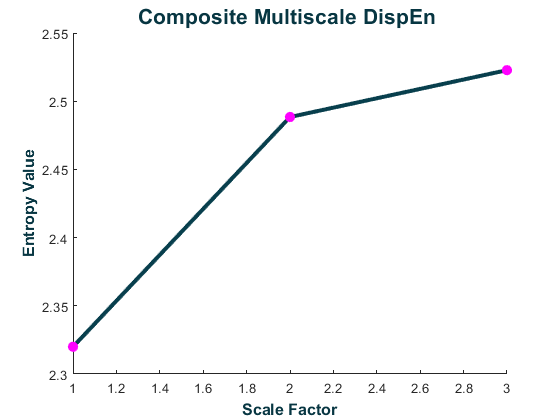

MSx = 1×3

2.3200 2.4884 2.5228

Ci = 7.3311

```matlab
[MSx, Ci] = cMSEn(X, Mobj, 'Plotx', true)
```

#### Example 4:

Import the x, y, and z components of the Lorenz system of equations and create a multiscale entropy object with the following parameters:

EnType = SampEn(), embedding dimension = 2, time delay = 1, radius distance threshold = 0.2*SD(X)

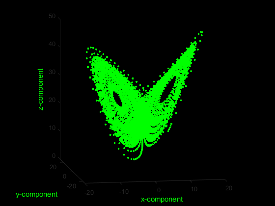

```matlab
Data = ExampleData('lorenz');
figure('Color', 'k')
plot3(Data(:,1), Data(:,2), Data(:,3), 'g.')
xlabel('x-component','color','g'),
ylabel('y-component','color','g'),
zlabel('z-component','color','g'),
view(-10,10), set(gca,'color','k'), axis square
```

```matlab
% The specified paramters are the default parameters for SampEn, and SampEn
% is the default entropy type returned by MSobject()
Mobj = MSobject()
```

Mobj = struct with fields:

Func: @SampEn

Calculate the refined-composite multiscale sample entropy and complexity index of the x-component over 5 temporal scales and return a plot of the multscale entropy curve.

. . . . . . . . . . . . . . . .

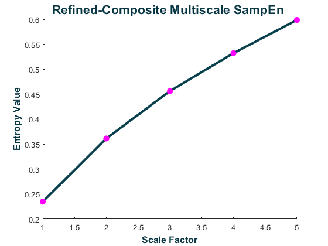

MSx = 1×5

0.2349 0.3613 0.4562 0.5322 0.5987

Ci = 2.1833

```matlab
X = Data(:,1);
[MSx, Ci] = cMSEn(X, Mobj, 'Scales', 5, 'Refined', true, 'Plotx', true)
```